# RS_Project

### 1. Import the necessary libraries and read the provided CSVs as a data frame and perform the below steps.

```python
#Importing libraries
import numpy as np
import pandas as pd
from scipy.stats import zscore
import seaborn as sns
import matplotlib.pyplot as plt
# To enable plotting graphs in Jupyter notebook
%matplotlib inline
```

```
Matplotlib is building the font cache; this may take a moment.
```

#### • Merge the provided CSVs into one data-frame.

```python
data1 = pd.read_csv('phone_user_review_file_1.csv',engine='python')
data2 = pd.read_csv('phone_user_review_file_2.csv',engine='python')
data3 = pd.read_csv('phone_user_review_file_3.csv',engine='python')
data4 = pd.read_csv('phone_user_review_file_4.csv',engine='python')
data5 = pd.read_csv('phone_user_review_file_5.csv',engine='python')
data6 = pd.read_csv('phone_user_review_file_6.csv',engine='python')
```

```python
print('shape of the data1',data1.shape)
print('shape of the data2',data2.shape)
print('shape of the data3',data3.shape)
print('shape of the data4',data4.shape)
print('shape of the data5',data5.shape)
print('shape of the data6',data6.shape)
```

```
shape of the data1 (374910, 11)
shape of the data2 (114925, 11)
shape of the data3 (312961, 11)
shape of the data4 (98284, 11)
shape of the data5 (350216, 11)
shape of the data6 (163837, 11)
```

```python
data1.head()
```

|  | phone_url | date | lang | country | source | domain | score | score_max | extract | author | product |
| --- | --- | --- | --- | --- | --- | --- | --- | --- | --- | --- | --- |
| 0 | /cellphones/samsung-galaxy-s8/ | 5/2/2017 | en | us | Verizon Wireless | verizonwireless.com | 10.0 | 10.0 | As a diehard Samsung fan who has had every Sam... | CarolAnn35 | Samsung Galaxy S8 |
| 1 | /cellphones/samsung-galaxy-s8/ | 4/28/2017 | en | us | Phone Arena | phonearena.com | 10.0 | 10.0 | Love the phone. the phone is sleek and smooth ... | james0923 | Samsung Galaxy S8 |
| 2 | /cellphones/samsung-galaxy-s8/ | 5/4/2017 | en | us | Amazon | amazon.com | 6.0 | 10.0 | Adequate feel. Nice heft. Processor's still sl... | R. Craig | Samsung Galaxy S8 (64GB) G950U 5.8" 4G LTE Unl... |
| 3 | /cellphones/samsung-galaxy-s8/ | 5/2/2017 | en | us | Samsung | samsung.com | 9.2 | 10.0 | Never disappointed. One of the reasons I've be... | Buster2020 | Samsung Galaxy S8 64GB (AT&T) |
| 4 | /cellphones/samsung-galaxy-s8/ | 5/11/2017 | en | us | Verizon Wireless | verizonwireless.com | 4.0 | 10.0 | I've now found that i'm in a group of people t... | S Ate Mine | Samsung Galaxy S8 |

```python
data2.head()
```

|  | phone_url | date | lang | country | source | domain | score | score_max | extract | author | product |
| --- | --- | --- | --- | --- | --- | --- | --- | --- | --- | --- | --- |
| 0 | /cellphones/leagoo-lead-7/ | 4/15/2015 | en | us | Amazon | amazon.com | 2.0 | 10.0 | The telephone headset is of poor quality , not... | luis | Leagoo Lead7 5.0 Inch HD JDI LTPS Screen 3G Sm... |
| 1 | /cellphones/leagoo-lead-7/ | 5/23/2015 | en | gb | Amazon | amazon.co.uk | 10.0 | 10.0 | This is my first smartphone so I have nothing ... | Mark Lavin | Leagoo Lead 7 Lead7 MTK6582 Quad core 1GB RAM ... |
| 2 | /cellphones/leagoo-lead-7/ | 4/27/2015 | en | gb | Amazon | amazon.co.uk | 8.0 | 10.0 | Great phone. Battery life not great but seems ... | tracey | Leagoo Lead 7 Lead7 MTK6582 Quad core 1GB RAM ... |
| 3 | /cellphones/leagoo-lead-7/ | 4/22/2015 | en | gb | Amazon | amazon.co.uk | 10.0 | 10.0 | Best 90 quid I've ever spent on a smart phone | Reuben Ingram | Leagoo Lead 7 Lead7 MTK6582 Quad core 1GB RAM ... |
| 4 | /cellphones/leagoo-lead-7/ | 4/18/2015 | en | gb | Amazon | amazon.co.uk | 10.0 | 10.0 | I m happy with this phone.it s very good.thx team | viorel | Leagoo Lead 7 Lead7 MTK6582 Quad core 1GB RAM ... |

```python
data3.head()
```

|  | phone_url | date | lang | country | source | domain | score | score_max | extract | author | product |
| --- | --- | --- | --- | --- | --- | --- | --- | --- | --- | --- | --- |
| 0 | /cellphones/samsung-galaxy-s-iii-slim-sm-g3812/ | 11/7/2015 | pt | br | Submarino | submarino.com.br | 6.0 | 10.0 | recomendo, eu comprei um, a um ano, e agora co... | herlington tesch | Samsung Smartphone Samsung Galaxy S3 Slim G381... |
| 1 | /cellphones/samsung-galaxy-s-iii-slim-sm-g3812/ | 10/2/2015 | pt | br | Submarino | submarino.com.br | 10.0 | 10.0 | Comprei um pouco desconfiada do site e do celu... | Luisa Silva Marieta | Samsung Smartphone Samsung Galaxy S3 Slim G381... |
| 2 | /cellphones/samsung-galaxy-s-iii-slim-sm-g3812/ | 9/2/2015 | pt | br | Submarino | submarino.com.br | 10.0 | 10.0 | Muito bom o produto, obvio que tem versões mel... | Cyrus | Samsung Smartphone Samsung Galaxy S3 Slim G381... |
| 3 | /cellphones/samsung-galaxy-s-iii-slim-sm-g3812/ | 9/2/2015 | pt | br | Submarino | submarino.com.br | 8.0 | 10.0 | Unica ressalva fica para a camera que poderia ... | Marcela Santa Clara Brito | Samsung Smartphone Samsung Galaxy S3 Slim G381... |
| 4 | /cellphones/samsung-galaxy-s-iii-slim-sm-g3812/ | 9/1/2015 | pt | br | Colombo | colombo.com.br | 8.0 | 10.0 | Rapidez e atenção na entrega. O aparelho é mui... | Claudine Maria Kuhn Walendorff | Smartphone Samsung Galaxy S3 Slim, Dual Chip, ... |

```python
data4.head()
```

|  | phone_url | date | lang | country | source | domain | score | score_max | extract | author | product |
| --- | --- | --- | --- | --- | --- | --- | --- | --- | --- | --- | --- |
| 0 | /cellphones/samsung-s7262-duos-galaxy-ace/ | 3/11/2015 | en | us | Amazon | amazon.com | 2.0 | 10.0 | was not conpatable with my phone as stated. I ... | Frances DeSimone | Samsung Galaxy Star Pro DUOS S7262 Unlocked Ce... |
| 1 | /cellphones/samsung-s7262-duos-galaxy-ace/ | 17/11/2015 | en | in | Zopper | zopper.com | 10.0 | 10.0 | Decent Functions and Easy to Operate Pros:- Th... | Expert Review | Samsung Galaxy Star Pro S7262 Black |
| 2 | /cellphones/samsung-s7262-duos-galaxy-ace/ | 29/10/2015 | en | in | Amazon | amazon.in | 4.0 | 10.0 | Not Good Phone such price. Hang too much and v... | Amazon Customer | Samsung Galaxy Star Pro GT-S7262 (Midnight Black) |
| 3 | /cellphones/samsung-s7262-duos-galaxy-ace/ | 29/10/2015 | en | in | Amazon | amazon.in | 6.0 | 10.0 | not bad for features | Amazon Customer | Samsung Galaxy Star Pro GT-S7262 (Midnight Black) |
| 4 | /cellphones/samsung-s7262-duos-galaxy-ace/ | 29/10/2015 | en | in | Amazon | amazon.in | 10.0 | 10.0 | Excellent product | NHK | Samsung Galaxy Star Pro GT-S7262 (Midnight Black) |

```python
data5.head()
```

|  | phone_url | date | lang | country | source | domain | score | score_max | extract | author | product |
| --- | --- | --- | --- | --- | --- | --- | --- | --- | --- | --- | --- |
| 0 | /cellphones/karbonn-k1616/ | 7/13/2016 | en | in | 91 Mobiles | 91mobiles.com | 2.0 | 10.0 | I bought 1 month before. currently speaker is ... | venkatesh | Karbonn K1616 |
| 1 | /cellphones/karbonn-k1616/ | 7/13/2016 | en | in | 91 Mobiles | 91mobiles.com | 6.0 | 10.0 | I just bought one week back, I have Airtel con... | Venkat | Karbonn K1616 |
| 2 | /cellphones/karbonn-k1616/ | 7/13/2016 | en | in | 91 Mobiles | 91mobiles.com | 4.0 | 10.0 | one problem in this handset opera is not worki... | krrish | Karbonn K1616 |
| 3 | /cellphones/karbonn-k1616/ | 4/25/2014 | en | in | Naaptol | naaptol.com | 10.0 | 10.0 | here Karbonn comes up with an another excellen... | BRIJESH CHAUHAN | Karbonn K1616 - Black |
| 4 | /cellphones/karbonn-k1616/ | 4/23/2013 | en | in | Naaptol | naaptol.com | 10.0 | 10.0 | What a phone, all so on Naaptol my god 23% off... | Suraj CHAUHAN | Karbonn K1616 - Black |

```python
data6.head()
```

|  | phone_url | date | lang | country | source | domain | score | score_max | extract | author | product |
| --- | --- | --- | --- | --- | --- | --- | --- | --- | --- | --- | --- |
| 0 | /cellphones/samsung-instinct-sph-m800/ | 9/16/2011 | en | us | Phone Arena | phonearena.com | 8.0 | 10.0 | I've had the phone for awhile and it's a prett... | ajabrams95 | Samsung Instinct HD |
| 1 | /cellphones/samsung-instinct-sph-m800/ | 2/13/2014 | en | us | Amazon | amazon.com | 6.0 | 10.0 | to be clear it is not the sellers fault that t... | Stephanie | Samsung SPH M800 Instinct |
| 2 | /cellphones/samsung-instinct-sph-m800/ | 12/30/2011 | en | us | Phone Scoop | phonescoop.com | 9.0 | 10.0 | Well i love this phone. i have had ton of phon... | snickers | Instinct M800 |
| 3 | /cellphones/samsung-instinct-sph-m800/ | 10/18/2008 | en | us | HandCellPhone | handcellphone.com | 4.0 | 10.0 | I have had my Instinct for several months now ... | A4C | Samsung Instinct |
| 4 | /cellphones/samsung-instinct-sph-m800/ | 9/6/2008 | en | us | Reviewed.com | reviewed.com | 6.0 | 10.0 | i have had this instinct phone for about two m... | betaBgood | Samsung Instinct |

```python
#merging the dataset
data = pd.concat([data1,data2,data3,data4,data5,data6],axis=0).reset_index(drop=True)
print('data Shape after merging the dataframes',data.shape)
```

```
data Shape after merging the dataframes (1415133, 11)
```

```python
data
```

|  | phone_url | date | lang | country | source | domain | score | score_max | extract | author | product |
| --- | --- | --- | --- | --- | --- | --- | --- | --- | --- | --- | --- |
| 0 | /cellphones/samsung-galaxy-s8/ | 5/2/2017 | en | us | Verizon Wireless | verizonwireless.com | 10.0 | 10.0 | As a diehard Samsung fan who has had every Sam... | CarolAnn35 | Samsung Galaxy S8 |
| 1 | /cellphones/samsung-galaxy-s8/ | 4/28/2017 | en | us | Phone Arena | phonearena.com | 10.0 | 10.0 | Love the phone. the phone is sleek and smooth ... | james0923 | Samsung Galaxy S8 |
| 2 | /cellphones/samsung-galaxy-s8/ | 5/4/2017 | en | us | Amazon | amazon.com | 6.0 | 10.0 | Adequate feel. Nice heft. Processor's still sl... | R. Craig | Samsung Galaxy S8 (64GB) G950U 5.8" 4G LTE Unl... |
| 3 | /cellphones/samsung-galaxy-s8/ | 5/2/2017 | en | us | Samsung | samsung.com | 9.2 | 10.0 | Never disappointed. One of the reasons I've be... | Buster2020 | Samsung Galaxy S8 64GB (AT&T) |
| 4 | /cellphones/samsung-galaxy-s8/ | 5/11/2017 | en | us | Verizon Wireless | verizonwireless.com | 4.0 | 10.0 | I've now found that i'm in a group of people t... | S Ate Mine | Samsung Galaxy S8 |
| ... | ... | ... | ... | ... | ... | ... | ... | ... | ... | ... | ... |
| 1415128 | /cellphones/alcatel-ot-club_1187/ | 5/12/2000 | de | de | Ciao | ciao.de | 2.0 | 10.0 | Weil mein Onkel bei ALcatel arbeitet habe ich ... | david.paul | Alcatel Club Plus Handy |
| 1415129 | /cellphones/alcatel-ot-club_1187/ | 5/11/2000 | de | de | Ciao | ciao.de | 10.0 | 10.0 | Hy Liebe Leserinnen und Leser!! Ich habe seit ... | Christiane14 | Alcatel Club Plus Handy |
| 1415130 | /cellphones/alcatel-ot-club_1187/ | 5/4/2000 | de | de | Ciao | ciao.de | 2.0 | 10.0 | Jetzt hat wohl Alcatell gedacht ,sie machen wa... | michaelawr | Alcatel Club Plus Handy |
| 1415131 | /cellphones/alcatel-ot-club_1187/ | 5/1/2000 | de | de | Ciao | ciao.de | 8.0 | 10.0 | Ich bin seit 2 Jahren (stolzer) Besitzer eines... | claudia0815 | Alcatel Club Plus Handy |
| 1415132 | /cellphones/alcatel-ot-club_1187/ | 4/25/2000 | de | de | Ciao | ciao.de | 2.0 | 10.0 | Was sich Alkatel hier wieder ausgedacht hat,sc... | michaelawr | Alcatel Club Plus Handy |

1415133 rows × 11 columns

```python
%who
```

```
Dataset	 KNNWithMeans	 Reader	 SVD	 accuracy	 data	 data1	 data2	 data3
data4	 data5	 data6	 np	 pd	 plt	 reader	 sns	 zscore
```

```python
del data1, data2, data3,data4,data5,data6
```

```python
%who
```

```
Dataset	 KNNWithMeans	 Reader	 SVD	 accuracy	 data	 np	 pd	 plt
reader	 sns	 zscore
```

```python
import gc
gc.collect()
```

```
115
```

#### • Check a few observations and shape of the data-frame.

```python
data.head()
```

|  | phone_url | date | lang | country | source | domain | score | score_max | extract | author | product |
| --- | --- | --- | --- | --- | --- | --- | --- | --- | --- | --- | --- |
| 0 | /cellphones/samsung-galaxy-s8/ | 5/2/2017 | en | us | Verizon Wireless | verizonwireless.com | 10.0 | 10.0 | As a diehard Samsung fan who has had every Sam... | CarolAnn35 | Samsung Galaxy S8 |
| 1 | /cellphones/samsung-galaxy-s8/ | 4/28/2017 | en | us | Phone Arena | phonearena.com | 10.0 | 10.0 | Love the phone. the phone is sleek and smooth ... | james0923 | Samsung Galaxy S8 |
| 2 | /cellphones/samsung-galaxy-s8/ | 5/4/2017 | en | us | Amazon | amazon.com | 6.0 | 10.0 | Adequate feel. Nice heft. Processor's still sl... | R. Craig | Samsung Galaxy S8 (64GB) G950U 5.8" 4G LTE Unl... |
| 3 | /cellphones/samsung-galaxy-s8/ | 5/2/2017 | en | us | Samsung | samsung.com | 9.2 | 10.0 | Never disappointed. One of the reasons I've be... | Buster2020 | Samsung Galaxy S8 64GB (AT&T) |
| 4 | /cellphones/samsung-galaxy-s8/ | 5/11/2017 | en | us | Verizon Wireless | verizonwireless.com | 4.0 | 10.0 | I've now found that i'm in a group of people t... | S Ate Mine | Samsung Galaxy S8 |

```python
data.shape
```

```
(1415133, 11)
```

#### • Round off scores to the nearest integers.

```python
data.info()
```

```
<class 'pandas.core.frame.DataFrame'>
RangeIndex: 1415133 entries, 0 to 1415132
Data columns (total 11 columns):
 #   Column     Non-Null Count    Dtype
---  ------     --------------    -----
 0   phone_url  1415133 non-null  object
 1   date       1415133 non-null  object
 2   lang       1415133 non-null  object
 3   country    1415133 non-null  object
 4   source     1415133 non-null  object
 5   domain     1415133 non-null  object
 6   score      1351644 non-null  float64
 7   score_max  1351644 non-null  float64
 8   extract    1395772 non-null  object
 9   author     1351931 non-null  object
 10  product    1415132 non-null  object
dtypes: float64(2), object(9)
memory usage: 118.8+ MB
```

```python
data.score.head(),data.score_max.head()
```

```
(0    10.0
 1    10.0
 2     6.0
 3     9.2
 4     4.0
 Name: score, dtype: float64,
 0    10.0
 1    10.0
 2    10.0
 3    10.0
 4    10.0
 Name: score_max, dtype: float64)
```

```python
#rounfing to the nearest integers
data.score = data.score.round(0)
data.score_max = data.score_max.round(0)
```

```python
data.score.head(),data.score_max.head()
```

```
(0    10.0
 1    10.0
 2     6.0
 3     9.0
 4     4.0
 Name: score, dtype: float64,
 0    10.0
 1    10.0
 2    10.0
 3    10.0
 4    10.0
 Name: score_max, dtype: float64)
```

#### • Drop irrelevant features. Keep features like Author, Product, and Score.

```python
data.head()
```

|  | phone_url | date | lang | country | source | domain | score | score_max | extract | author | product |
| --- | --- | --- | --- | --- | --- | --- | --- | --- | --- | --- | --- |
| 0 | /cellphones/samsung-galaxy-s8/ | 5/2/2017 | en | us | Verizon Wireless | verizonwireless.com | 10.0 | 10.0 | As a diehard Samsung fan who has had every Sam... | CarolAnn35 | Samsung Galaxy S8 |
| 1 | /cellphones/samsung-galaxy-s8/ | 4/28/2017 | en | us | Phone Arena | phonearena.com | 10.0 | 10.0 | Love the phone. the phone is sleek and smooth ... | james0923 | Samsung Galaxy S8 |
| 2 | /cellphones/samsung-galaxy-s8/ | 5/4/2017 | en | us | Amazon | amazon.com | 6.0 | 10.0 | Adequate feel. Nice heft. Processor's still sl... | R. Craig | Samsung Galaxy S8 (64GB) G950U 5.8" 4G LTE Unl... |
| 3 | /cellphones/samsung-galaxy-s8/ | 5/2/2017 | en | us | Samsung | samsung.com | 9.0 | 10.0 | Never disappointed. One of the reasons I've be... | Buster2020 | Samsung Galaxy S8 64GB (AT&T) |
| 4 | /cellphones/samsung-galaxy-s8/ | 5/11/2017 | en | us | Verizon Wireless | verizonwireless.com | 4.0 | 10.0 | I've now found that i'm in a group of people t... | S Ate Mine | Samsung Galaxy S8 |

```python
data.columns
```

```
Index(['phone_url', 'date', 'lang', 'country', 'source', 'domain', 'score',
       'score_max', 'extract', 'author', 'product'],
      dtype='object')
```

```python
#dropping irrelevant features - 'phone_url', 'date', 'lang', 'country', 'source', 'domain', 'score_max','extract'
data = data[['author','product','score']]
data.head()
```

|  | author | product | score |
| --- | --- | --- | --- |
| 0 | CarolAnn35 | Samsung Galaxy S8 | 10.0 |
| 1 | james0923 | Samsung Galaxy S8 | 10.0 |
| 2 | R. Craig | Samsung Galaxy S8 (64GB) G950U 5.8" 4G LTE Unl... | 6.0 |
| 3 | Buster2020 | Samsung Galaxy S8 64GB (AT&T) | 9.0 |
| 4 | S Ate Mine | Samsung Galaxy S8 | 4.0 |

#### • Check for missing values. Impute the missing values if there is any.

```python
data.isna().sum()
#there are missing values
```

```
author     63202
product        1
score      63489
dtype: int64
```

```python
#since there is no point in imputing author name, we are dropping the rows where there is missing author
data = data[~data.author.isna()]
```

```python
data.shape
```

```
(1351931, 3)
```

```python
#checking if the score column has nulls after removing null authors
data.isna().sum()
```

```
author         0
product        0
score      60893
dtype: int64
```

```python
# replacing the null score by mean.
data.score.fillna(data.score.mean(),inplace=True)
```

```python
data.isna().sum()
#all nulls are replaced
```

```
author     0
product    0
score      0
dtype: int64
```

#### • Check for duplicate values and remove them if there is any.

```python
data.shape
```

```
(1351931, 3)
```

```python
data.duplicated().sum()
```

```
137155
```

```python
#droping the duplicates
data.drop_duplicates(inplace=True)
data.shape
```

```
(1214776, 3)
```

#### • Keep only 1000000 data samples. Use random state=612.

```python
data_sampled = data.sample(n=1000000,random_state=612).reset_index(drop=True)
```

```python
data_sampled.head()
```

|  | author | product | score |
| --- | --- | --- | --- |
| 0 | Lynx | LG Electronics Google Nexus 5 Android puhelin ... | 10.0 |
| 1 | J de Droog | Apple iPhone 5S 16GB Black | 8.0 |
| 2 | Marek | Samsung S5611 weiß | 4.0 |
| 3 | Em | LG Cosmos Touch VN270 - for Post-Paid Verizon ... | 8.0 |
| 4 | Peter S. | Microsoft Nokia 3110 classic black (Bluetooth,... | 8.0 |

```python
data_sampled.shape
```

```
(1000000, 3)
```

### 2. Answer the following questions

#### • Identify the most rated features.

```python
#most rated products
most_rated_product = pd.DataFrame(data_sampled.groupby(by='product')['product'].count().sort_values(ascending=False))
most_rated_product.head(20)
```

| product | product |
| --- | --- |
| OnePlus 3 (Graphite, 64 GB) | 1835 |
| Lenovo Vibe K4 Note (White,16GB) | 1728 |
| Lenovo Vibe K4 Note (Black, 16GB) | 1511 |
| Nokia N95 | 1495 |
| Samsung Galaxy J3 (8GB) | 1487 |
| OnePlus 3 (Soft Gold, 64 GB) | 1462 |
| Samsung Galaxy S7 edge 32GB (Verizon) | 1417 |
| Samsung Galaxy S7 edge 32GB (T-Mobile) | 1360 |
| Samsung Galaxy S6 zwart / 32 GB | 1343 |
| Nokia 5800 XpressMusic | 1328 |
| Samsung Galaxy S7 32GB (Verizon) | 1280 |
| Nokia 5800 | 1260 |
| Samsung Galaxy S7 32GB (T-Mobile) | 1214 |
| Nokia N8 | 1191 |
| LG GX200 | 1155 |
| Samsung Galaxy S5 16GB (Verizon) | 1104 |
| Samsung Galaxy S7 edge 32GB (AT&T) | 1085 |
| Huawei P8lite zwart / 16 GB | 1070 |
| Nokia 5530 XpressMusic | 1036 |
| Nokia N97 | 1000 |

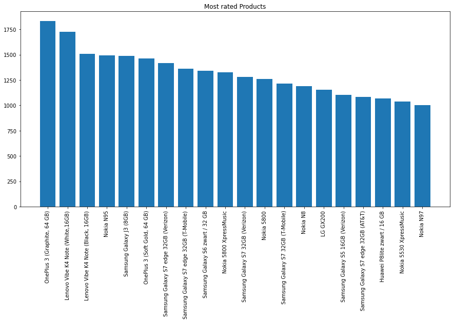

```python
# 20 Most rated Products
plt.figure(figsize=(15,7))
plt.bar(most_rated_product.index[0:20],most_rated_product['product'].head(20))
plt.xticks(rotation = 90)
plt.title('Most rated Products')
plt.show()
```

```python
### Get the product Company
DiffCompany = {}
for item in range(len(data_sampled)):
    a = str(data_sampled.loc[item,'product'].split()[0])
    if a not in DiffCompany:
        DiffCompany[a] = 1
    else:
        DiffCompany[a] += 1
```

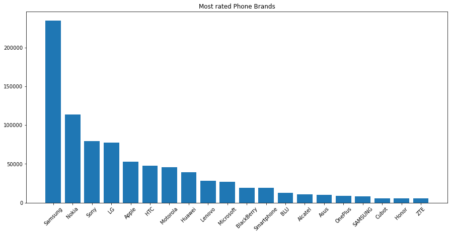

```python
# 20 Most rated Phone Brand
from collections import Counter
X = dict(Counter(DiffCompany).most_common(20))
plt.figure(figsize=(15,7))
plt.bar(*zip(*X.items()))
plt.xticks(rotation = 45)
plt.title('Most rated Phone Brands')
plt.show()
```

#### • Identify the users with most number of reviews.

```python
# 20 users with most reviews.
most_rated_user = pd.DataFrame(data_sampled.groupby(by='author')['author'].count().sort_values(ascending=False))
most_rated_user.head(20)
```

| author | author |
| --- | --- |
| Amazon Customer | 13857 |
| Cliente Amazon | 5274 |
| Client d'Amazon | 2217 |
| Amazon Kunde | 1648 |
| Anonymous | 1568 |
| David | 752 |
| Alex | 677 |
| Marco | 569 |
| Daniel | 564 |
| Александр | 545 |
| Andrea | 536 |
| Chris | 518 |
| Michael | 499 |
| Дмитрий | 476 |
| Antonio | 474 |
| Сергей | 458 |
| Kindle Customer | 448 |
| Андрей | 440 |
| e-bit | 438 |
| Alessandro | 408 |

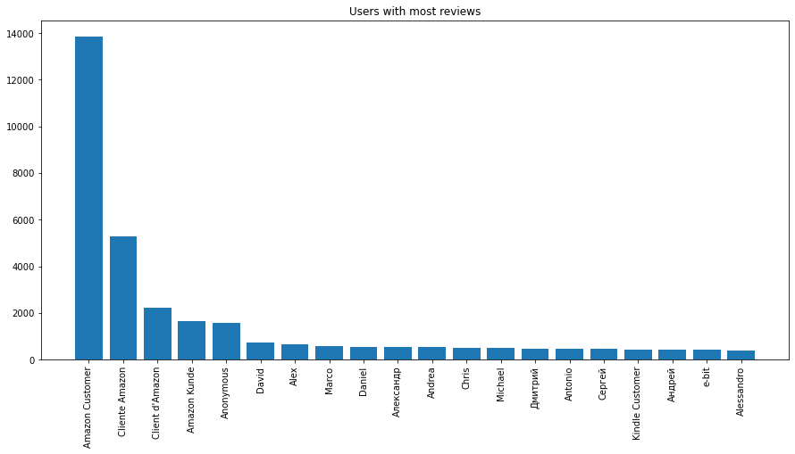

```python
# 20 users with most reviews.
plt.figure(figsize=(15,7))
plt.bar(most_rated_user.index[0:20],most_rated_user['author'].head(20))
plt.xticks(rotation = 90)
plt.title('Users with most reviews')
plt.show()
```

#### • Select the data with products having more than 50 ratings and users who have given more than 50 ratings. Report the shape of the final dataset.

```python
df = data_sampled[(data_sampled['product'].isin(most_rated_product[most_rated_product['product']>50].index)) & (data_sampled['author'].isin(most_rated_user[most_rated_user['author']>50].index))]
df = df.reset_index(drop=True)
df
```

|  | author | product | score |
| --- | --- | --- | --- |
| 0 | Paolo | Asus ZenFone 3 Smartphone, Display da 5.2", Me... | 10.0 |
| 1 | Sebastian | LG Electronics Google Nexus 5 Smartphone (4,95... | 2.0 |
| 2 | Vincenzo | LG Optimus L5 II E460 Smartphone, Nero [Italia] | 8.0 |
| 3 | lorenzo | Honor 6 - Smartphone libre (pantalla de 5", 16... | 10.0 |
| 4 | David | LG Optimus L5 - Smartphone libre (pantalla t??... | 8.0 |
| ... | ... | ... | ... |
| 47912 | martin | Nokia 6280 | 10.0 |
| 47913 | Илья | Sony Xperia L (белый) | 10.0 |
| 47914 | Amazon Customer | BLU Studio M HD - 5.0" Smartphone -Global GSM ... | 2.0 |
| 47915 | Татьяна | Sony Xperia C (белый) | 6.0 |
| 47916 | Susan | Verizon WIRELESS CELL PHONE SAMSUNG U460 INTEN... | 10.0 |

47917 rows × 3 columns

```python
#shape of the final dataset
df.shape
```

```
(47917, 3)
```

### 3. Build a popularity based model and recommend top 5 mobile phones.

```python
df.groupby('product')['score'].mean().sort_values(ascending=False).head()
```

```
product
3100 / 3120                                   10.0
Nokia C2-01 Sim Free Mobile Phone - Silver    10.0
Pearl 8100                                    10.0
BlackBerry Pearl Flip 8220                    10.0
OnePlus One 64Gb                              10.0
Name: score, dtype: float64
```

```python
df.groupby('product')['score'].count().sort_values(ascending=False).head()
```

```
product
Apple iPhone 5s 16GB (серебристый)                                                                                                                                                           178
Huawei P8 Lite Smartphone, Display 5" IPS, Processore Octa-Core 1.5 GHz, Memoria Interna da 16 GB, 2 GB RAM, Fotocamera 13 MP, monoSIM, Android 5.0, Bianco [Italia]                         171
Huawei P9 Lite Smartphone, LTE, Display 5.2'' FHD, Processore Octa-Core Kirin 650, 16 GB Memoria Interna, 3GB RAM, Fotocamera 13 MP, Single-SIM, Android 6.0 Marshmallow, Bianco [Italia]    161
Huawei P8 lite Smartphone, Display 5.0" IPS, Dual Sim, Processore Octa-Core, Memoria 16 GB, Fotocamera 13 MP, Android 5.0, Bianco                                                            155
Lenovo Motorola Moto G Smartphone, 4,5 pollici display HD, processore Qualcomm, memoria 16GB, MicroSIM, Android 4.3 OS, fotocamera da 5 MP, Nero [Germania]                                  152
Name: score, dtype: int64
```

```python
product_mean_score = pd.DataFrame(df.groupby('product')['score'].mean())
product_mean_score.rename(columns = {'score': 'score_mean'},inplace=True)
```

```python
product_mean_score['score_counts'] = pd.DataFrame(df.groupby('product')['score'].count())
```

```python
product_mean_score.head()
```

| product | score_mean | score_counts |
| --- | --- | --- |
| 3100 / 3120 | 10.000000 | 1 |
| 3220 | 10.000000 | 1 |
| 5.5-Inch Unlocked Lenovo A850 3G Smartphone-(960x540) Quad Core 4GB MT6582m 1331MHz Android 4.2 Dual Camera +Dual SIM -Black (Rooted + Google Play) | 6.500000 | 4 |
| AICEK Coque ASUS ZenFone 3 Max ZC520TL, AICEK Etui Silicone Gel ASUS ZenFone 3 Max Housse Antichoc ZenFone 3 Max Transparente Souple Coque de Protection pour ASUS ZenFone 3 Max(5.2 Pouces) | 8.000000 | 4 |
| AICEK Coque Samsung Galaxy A3 2016, AICEK Etui Silicone Gel Samsung Galaxy A3 2016 (A310F) Housse Antichoc Samsung A3 Transparente Souple Coque De Protection Pour Samsung Galaxy A3 2016 (4,7 pouces) | 8.133333 | 15 |

```python
#Sort the products on recommendation score_counts and score mean
train_data_sort = product_mean_score.sort_values(['score_counts','score_mean'], ascending = [0,0])
train_data_sort.head()
```

| product | score_mean | score_counts |
| --- | --- | --- |
| Apple iPhone 5s 16GB (серебристый) | 8.406478 | 178 |
| Huawei P8 Lite Smartphone, Display 5" IPS, Processore Octa-Core 1.5 GHz, Memoria Interna da 16 GB, 2 GB RAM, Fotocamera 13 MP, monoSIM, Android 5.0, Bianco [Italia] | 8.187135 | 171 |
| Huawei P9 Lite Smartphone, LTE, Display 5.2'' FHD, Processore Octa-Core Kirin 650, 16 GB Memoria Interna, 3GB RAM, Fotocamera 13 MP, Single-SIM, Android 6.0 Marshmallow, Bianco [Italia] | 8.720497 | 161 |
| Huawei P8 lite Smartphone, Display 5.0" IPS, Dual Sim, Processore Octa-Core, Memoria 16 GB, Fotocamera 13 MP, Android 5.0, Bianco | 8.670968 | 155 |
| Lenovo Motorola Moto G Smartphone, 4,5 pollici display HD, processore Qualcomm, memoria 16GB, MicroSIM, Android 4.3 OS, fotocamera da 5 MP, Nero [Germania] | 9.144737 | 152 |

```python
#Generate a recommendation rank based upon score_counts
train_data_sort['Rank'] = train_data_sort['score_counts'].rank(ascending=0, method='first')
```

```python
#top 5 recommendations for mobile phones
popularity_recommendations = train_data_sort.head(5)
popularity_recommendations
```

| product | score_mean | score_counts | Rank |
| --- | --- | --- | --- |
| Apple iPhone 5s 16GB (серебристый) | 8.406478 | 178 | 1.0 |
| Huawei P8 Lite Smartphone, Display 5" IPS, Processore Octa-Core 1.5 GHz, Memoria Interna da 16 GB, 2 GB RAM, Fotocamera 13 MP, monoSIM, Android 5.0, Bianco [Italia] | 8.187135 | 171 | 2.0 |
| Huawei P9 Lite Smartphone, LTE, Display 5.2'' FHD, Processore Octa-Core Kirin 650, 16 GB Memoria Interna, 3GB RAM, Fotocamera 13 MP, Single-SIM, Android 6.0 Marshmallow, Bianco [Italia] | 8.720497 | 161 | 3.0 |
| Huawei P8 lite Smartphone, Display 5.0" IPS, Dual Sim, Processore Octa-Core, Memoria 16 GB, Fotocamera 13 MP, Android 5.0, Bianco | 8.670968 | 155 | 4.0 |
| Lenovo Motorola Moto G Smartphone, 4,5 pollici display HD, processore Qualcomm, memoria 16GB, MicroSIM, Android 4.3 OS, fotocamera da 5 MP, Nero [Germania] | 9.144737 | 152 | 5.0 |

```python
# top 5 recommendations per user
def pb_recommend(user):
    print('**Recommending top ' + str(5)+ ' products for userid : ' + user + ' ...**')
    df = popularity_recommendations.copy()
    df['user']=user
    df.reset_index(inplace=True)
    df = df[['user','product', 'score_mean','score_counts','Rank']]
    return df
```

```python
pb_recommend('Alex')
```

```
**Recommending top 5 products for userid : Alex ...**
```

|  | user | product | score_mean | score_counts | Rank |
| --- | --- | --- | --- | --- | --- |
| 0 | Alex | Apple iPhone 5s 16GB (серебристый) | 8.406478 | 178 | 1.0 |
| 1 | Alex | Huawei P8 Lite Smartphone, Display 5" IPS, Pro... | 8.187135 | 171 | 2.0 |
| 2 | Alex | Huawei P9 Lite Smartphone, LTE, Display 5.2'' ... | 8.720497 | 161 | 3.0 |
| 3 | Alex | Huawei P8 lite Smartphone, Display 5.0" IPS, D... | 8.670968 | 155 | 4.0 |
| 4 | Alex | Lenovo Motorola Moto G Smartphone, 4,5 pollici... | 9.144737 | 152 | 5.0 |

```python
pb_recommend('Nicola')
```

```
**Recommending top 5 products for userid : Nicola ...**
```

|  | user | product | score_mean | score_counts | Rank |
| --- | --- | --- | --- | --- | --- |
| 0 | Nicola | Apple iPhone 5s 16GB (серебристый) | 8.406478 | 178 | 1.0 |
| 1 | Nicola | Huawei P8 Lite Smartphone, Display 5" IPS, Pro... | 8.187135 | 171 | 2.0 |
| 2 | Nicola | Huawei P9 Lite Smartphone, LTE, Display 5.2'' ... | 8.720497 | 161 | 3.0 |
| 3 | Nicola | Huawei P8 lite Smartphone, Display 5.0" IPS, D... | 8.670968 | 155 | 4.0 |
| 4 | Nicola | Lenovo Motorola Moto G Smartphone, 4,5 pollici... | 9.144737 | 152 | 5.0 |

### 4. Build a collaborative filtering model using SVD. You can use SVD from surprise or build it from scratch(Note: Incase you’re building it from scratch you can limit your data points to 5000 samples if you face memory issues). Build a collaborative filtering model using kNNWithMeans from surprise. You can try both user-based and item-based model.

```python
from surprise import Dataset,Reader
from surprise import SVD, KNNWithMeans
from surprise import accuracy
```

#### SVD Based Recommendation System

```python
reader = Reader(rating_scale=(1, 10))
data = Dataset.load_from_df(df[['author', 'product', 'score']], reader)
```

```python
# Split data to train and test
from surprise.model_selection import train_test_split
trainset, testset = train_test_split(data, test_size=.25,random_state=1)

# to build on full data
#trainset = data.build_full_trainset()
```

```python
trainset.n_ratings
```

```
35937
```

```python
j=1
for i in trainset.all_ratings():
    print(i)
    j+=1
    if j>5:
        break
```

```
(0, 0, 8.0)
(0, 593, 8.0)
(0, 675, 8.0)
(0, 1437, 6.0)
(0, 524, 2.0)
```

```python
svd_model = SVD(n_factors=5,random_state=123)
svd_model.fit(trainset)

test_pred = svd_model.test(testset)
print('Test RMSE is - ',accuracy.rmse(test_pred))
```

```
RMSE: 2.6826
Test RMSE is -  2.6826442584367665
```

```python
# hyper-parameter tuning SVD
from surprise.model_selection import GridSearchCV,RepeatedKFold

param_grid = {'n_factors': [2,5,10,20,50],'n_epochs': [20,30], 'lr_all': [0.005,0.01],'reg_all':[0.02,0.1],'biased':[False,True]}
cv = RepeatedKFold(n_splits=5, n_repeats=1, random_state=123)
gs = GridSearchCV(SVD, param_grid, measures=['rmse'], cv=cv,n_jobs=-1)
gs.fit(data)
params = gs.best_params['rmse']

svdtuned = SVD(n_factors=params['n_factors'], n_epochs=params['n_epochs'],lr_all=params['lr_all'], reg_all=params['reg_all'],
              biased=params['biased'])
svdtuned.fit(trainset)

test_pred_svdtuned = svdtuned.test(testset)
print('Test RMSE is - ',accuracy.rmse(test_pred_svdtuned))
```

```
RMSE: 2.5490
Test RMSE is -  2.5489924115617777
```

### KNNWithMeans User-based

```python
from surprise import KNNWithMeans
from surprise import accuracy
```

```python
knn_user = KNNWithMeans(k=10, sim_options={ 'user_based': True})
knn_user.fit(trainset)

print('')
test_pred_user=knn_user.test(testset)
print(accuracy.rmse(test_pred_user))
```

```
Computing the msd similarity matrix...
Done computing similarity matrix.

RMSE: 2.9483
2.9483059627244907
```

```python
# hyper-parameter tuning KNNWithMeans user_based

param_grid = {'k': [3,5,10,15,20,30,40],'min_k': [1,3,5],
              'sim_options': {'name': ['cosine','msd','pearson','pearson_baseline'],'user_based': [True]}}

cv = RepeatedKFold(n_splits=5, n_repeats=1, random_state=123)
gs = GridSearchCV(KNNWithMeans, param_grid, measures=['rmse'], cv=cv,n_jobs=-1)
gs.fit(data)
params = gs.best_params['rmse']

knnusertuned = KNNWithMeans(k=params['k'], min_k=params['min_k'], sim_options=params['sim_options'])
knnusertuned.fit(trainset)

test_pred_knnusertuned = knnusertuned.test(testset)
print('Test RMSE is - ',accuracy.rmse(test_pred_knnusertuned))
```

```
Computing the cosine similarity matrix...
Done computing similarity matrix.
RMSE: 2.5718
Test RMSE is -  2.5718384233062244
```

### KNNWithMeans Item-based

```python
knn_item = KNNWithMeans(k=10, sim_options={ 'user_based': False})
knn_item.fit(trainset)

print('')
test_pred_item=knn_item.test(testset)
print(accuracy.rmse(test_pred_item))
```

```
Computing the msd similarity matrix...
Done computing similarity matrix.

RMSE: 2.9797
2.979716469987771
```

```python
# hyper-parameter tuning KNNWithMeans item_based

param_grid = {'k': [3,5,10,15,20,30,40],'min_k': [1,3,5],
              'sim_options': {'name': ['cosine','msd','pearson','pearson_baseline'],'user_based': [False]}}

cv = RepeatedKFold(n_splits=5, n_repeats=1, random_state=123)
gs = GridSearchCV(KNNWithMeans, param_grid, measures=['rmse'], cv=cv,n_jobs=-1)
gs.fit(data)
params = gs.best_params['rmse']

knnitemtuned = KNNWithMeans(k=params['k'], min_k=params['min_k'], sim_options=params['sim_options'])
knnitemtuned.fit(trainset)

test_pred_knnitemtuned = knnitemtuned.test(testset)
print('Test RMSE is - ',accuracy.rmse(test_pred_knnitemtuned))
```

```
Computing the cosine similarity matrix...
Done computing similarity matrix.
RMSE: 2.6836
Test RMSE is -  2.683564825254916
```

#### 5. Evaluate the collaborative model. Print RMSE value.

```python
print('Test RMSE for Tuned SVD model is - ',accuracy.rmse(test_pred_svdtuned))
print('Test RMSE for Tuned KNNWithMeans User-Based model is - ',accuracy.rmse(test_pred_knnusertuned))
print('Test RMSE for Tuned KNNWithMeans Item-Based model is - ',accuracy.rmse(test_pred_knnitemtuned))
```

```
RMSE: 2.5490
Test RMSE for Tuned SVD model is -  2.5489924115617777
RMSE: 2.5718
Test RMSE for Tuned KNNWithMeans User-Based model is -  2.5718384233062244
RMSE: 2.6836
Test RMSE for Tuned KNNWithMeans Item-Based model is -  2.683564825254916
```

- SVD is performing best here, second KNNWithMeans User-Based, third KNNWithMeans Item-based

#### 6. Predict score (average rating) for test users.

```python
#prediction for test users by SVD model
pred_df_svdtuned=pd.DataFrame(test_pred_svdtuned)
pred_df_svdtuned
```

|  | uid | iid | r_ui | est | details |
| --- | --- | --- | --- | --- | --- |
| 0 | Валерий | LG X power (белый) | 8.011769 | 7.645369 | {'was_impossible': False} |
| 1 | Benjamin | Sony Ericsson K610i Evening Red UMTS Handy | 10.000000 | 8.395298 | {'was_impossible': False} |
| 2 | ?????????????? ???????????? | Samsung Galaxy Nexus GT-I9250 | 10.000000 | 7.760747 | {'was_impossible': False} |
| 3 | nicola | Nokia Lumia 625 Smartphone, Nero [Italia] | 10.000000 | 8.692473 | {'was_impossible': False} |
| 4 | Иван | Samsung Galaxy J5 (2016) | 8.000000 | 8.127659 | {'was_impossible': False} |
| ... | ... | ... | ... | ... | ... |
| 11975 | Igor | Samsung I8190 Galaxy S III mini 8GB (белый) | 9.000000 | 8.619216 | {'was_impossible': False} |
| 11976 | Amazon Customer | Samsung Galaxy Note 4 N910C Unlocked Cellphone... | 2.000000 | 7.019624 | {'was_impossible': False} |
| 11977 | Вадим | Alcatel OneTouch 800 | 10.000000 | 8.482442 | {'was_impossible': False} |
| 11978 | maurizio | Asus ZenFone 3 Smartphone, Display da 5.2", Me... | 6.000000 | 8.510987 | {'was_impossible': False} |
| 11979 | Amazon Customer | Tracfone LG Optimus Dynamic II - LG39C - Andro... | 10.000000 | 6.876069 | {'was_impossible': False} |

11980 rows × 5 columns

```python
#averagre prediction group by test users by SVD model
x = pred_df_svdtuned.groupby('uid').mean()
x['count'] = pred_df_svdtuned.groupby('uid').count()['details']
x.sort_values('count',ascending=False)
```

| uid | r_ui | est | count |
| --- | --- | --- | --- |
| Amazon Customer | 6.531897 | 6.674824 | 1207 |
| Cliente Amazon | 6.475836 | 6.761262 | 269 |
| Amazon Kunde | 6.601942 | 6.406458 | 206 |
| Client d'Amazon | 6.211382 | 6.505970 | 123 |
| Alex | 8.682353 | 8.289803 | 107 |
| ... | ... | ... | ... |
| kardelen | 8.011769 | 7.993559 | 1 |
| huliye | 8.011769 | 8.008996 | 1 |
| iboibo | 8.011769 | 7.992290 | 1 |
| retkit | 8.011769 | 7.972093 | 1 |
| kyef | 8.011769 | 7.994683 | 1 |

691 rows × 3 columns

```python
#prediction for test users by KNNWithMeans User-Based model
pred_df_knnusertuned=pd.DataFrame(test_pred_knnusertuned)
pred_df_knnusertuned
```

|  | uid | iid | r_ui | est | details |
| --- | --- | --- | --- | --- | --- |
| 0 | Валерий | LG X power (белый) | 8.011769 | 7.808171 | {'actual_k': 3, 'was_impossible': False} |
| 1 | Benjamin | Sony Ericsson K610i Evening Red UMTS Handy | 10.000000 | 8.300000 | {'actual_k': 1, 'was_impossible': False} |
| 2 | ?????????????? ???????????? | Samsung Galaxy Nexus GT-I9250 | 10.000000 | 7.515152 | {'actual_k': 2, 'was_impossible': False} |
| 3 | nicola | Nokia Lumia 625 Smartphone, Nero [Italia] | 10.000000 | 8.053251 | {'actual_k': 3, 'was_impossible': False} |
| 4 | Иван | Samsung Galaxy J5 (2016) | 8.000000 | 8.023530 | {'actual_k': 3, 'was_impossible': False} |
| ... | ... | ... | ... | ... | ... |
| 11975 | Igor | Samsung I8190 Galaxy S III mini 8GB (белый) | 9.000000 | 8.637434 | {'actual_k': 3, 'was_impossible': False} |
| 11976 | Amazon Customer | Samsung Galaxy Note 4 N910C Unlocked Cellphone... | 2.000000 | 6.493249 | {'actual_k': 3, 'was_impossible': False} |
| 11977 | Вадим | Alcatel OneTouch 800 | 10.000000 | 7.857950 | {'was_impossible': True, 'reason': 'User and/o... |
| 11978 | maurizio | Asus ZenFone 3 Smartphone, Display da 5.2", Me... | 6.000000 | 8.200392 | {'actual_k': 3, 'was_impossible': False} |
| 11979 | Amazon Customer | Tracfone LG Optimus Dynamic II - LG39C - Andro... | 10.000000 | 6.493249 | {'actual_k': 3, 'was_impossible': False} |

11980 rows × 5 columns

```python
#averagre prediction group by test users by KNNWithMeans User-Based model
x = pred_df_knnusertuned.groupby('uid').mean()
x['count'] = pred_df_knnusertuned.groupby('uid').count()['details']
x.sort_values('count',ascending=False)
```

| uid | r_ui | est | count |
| --- | --- | --- | --- |
| Amazon Customer | 6.531897 | 6.501163 | 1207 |
| Cliente Amazon | 6.475836 | 6.578199 | 269 |
| Amazon Kunde | 6.601942 | 6.425592 | 206 |
| Client d'Amazon | 6.211382 | 6.335063 | 123 |
| Alex | 8.682353 | 8.309096 | 107 |
| ... | ... | ... | ... |
| kardelen | 8.011769 | 8.011769 | 1 |
| huliye | 8.011769 | 8.011769 | 1 |
| iboibo | 8.011769 | 8.011769 | 1 |
| retkit | 8.011769 | 8.011769 | 1 |
| kyef | 8.011769 | 8.011769 | 1 |

691 rows × 3 columns

```python
#prediction for test users by KNNWithMeans Item-Based model
pred_df_knnitemtuned=pd.DataFrame(test_pred_knnitemtuned)
pred_df_knnitemtuned
```

|  | uid | iid | r_ui | est | details |
| --- | --- | --- | --- | --- | --- |
| 0 | Валерий | LG X power (белый) | 8.011769 | 8.209886 | {'actual_k': 3, 'was_impossible': False} |
| 1 | Benjamin | Sony Ericsson K610i Evening Red UMTS Handy | 10.000000 | 10.000000 | {'actual_k': 3, 'was_impossible': False} |
| 2 | ?????????????? ???????????? | Samsung Galaxy Nexus GT-I9250 | 10.000000 | 8.000000 | {'actual_k': 3, 'was_impossible': False} |
| 3 | nicola | Nokia Lumia 625 Smartphone, Nero [Italia] | 10.000000 | 9.285714 | {'actual_k': 3, 'was_impossible': False} |
| 4 | Иван | Samsung Galaxy J5 (2016) | 8.000000 | 8.629630 | {'actual_k': 3, 'was_impossible': False} |
| ... | ... | ... | ... | ... | ... |
| 11975 | Igor | Samsung I8190 Galaxy S III mini 8GB (белый) | 9.000000 | 8.473011 | {'actual_k': 3, 'was_impossible': False} |
| 11976 | Amazon Customer | Samsung Galaxy Note 4 N910C Unlocked Cellphone... | 2.000000 | 8.000000 | {'actual_k': 3, 'was_impossible': False} |
| 11977 | Вадим | Alcatel OneTouch 800 | 10.000000 | 7.857950 | {'was_impossible': True, 'reason': 'User and/o... |
| 11978 | maurizio | Asus ZenFone 3 Smartphone, Display da 5.2", Me... | 6.000000 | 8.645161 | {'actual_k': 3, 'was_impossible': False} |
| 11979 | Amazon Customer | Tracfone LG Optimus Dynamic II - LG39C - Andro... | 10.000000 | 7.714286 | {'actual_k': 3, 'was_impossible': False} |

11980 rows × 5 columns

```python
#averagre prediction group by test users by KNNWithMeans Item-Based model
x = pred_df_knnitemtuned.groupby('uid').mean()
x['count'] = pred_df_knnitemtuned.groupby('uid').count()['details']
x.sort_values('count',ascending=False)
```

| uid | r_ui | est | count |
| --- | --- | --- | --- |
| Amazon Customer | 6.531897 | 7.152379 | 1207 |
| Cliente Amazon | 6.475836 | 8.150444 | 269 |
| Amazon Kunde | 6.601942 | 7.547604 | 206 |
| Client d'Amazon | 6.211382 | 7.285167 | 123 |
| Alex | 8.682353 | 7.766704 | 107 |
| ... | ... | ... | ... |
| kardelen | 8.011769 | 8.011769 | 1 |
| huliye | 8.011769 | 8.011769 | 1 |
| iboibo | 8.011769 | 8.011769 | 1 |
| retkit | 8.011769 | 8.011769 | 1 |
| kyef | 8.011769 | 8.011769 | 1 |

691 rows × 3 columns

#### 7. Report your findings and inferences.

- Test RMSE for Tuned SVD model is - 2.5489924115617777
- Test RMSE for Tuned KNNWithMeans User-Based model is - 2.5718384233062244
- Test RMSE for Tuned KNNWithMeans Item-Based model is - 2.683564825254916
- SVD is performing best here, second KNNWithMeans User-Based, third KNNWithMeans Item-based
- Final Model selcted is the SVD tuned model
- Average prediction of users are close to the real average predictions. RMSE is liitle higher due to the rating scale (1,10)
- The Popularity-based recommender system is non-personalised and the recommendations are based on frequecy counts, which may be not suitable to the user. It gives the same recommendation for every users.
- User-based Collaborative Filtering is a personalised recommender system, the recommendations are based on the past behavior of the user and it is not dependent on any additional information. It gives the different recommendation for different users based on its nearest neighbou users.
- Item-based Collaborative Filtering is a personalised recommender system, the recommendations are based similar items. It gives the different recommendation for different users based on the items they have rated.

#### 8. Try and recommend top 5 products for test users.

```python
pd.DataFrame(testset)[0].value_counts()
```

```
Amazon Customer    1207
Cliente Amazon      269
Amazon Kunde        206
Client d'Amazon     123
Alex                107
                   ...
gulayy                1
eric                  1
kardelen              1
iboibo                1
umoo                  1
Name: 0, Length: 691, dtype: int64
```

```python
from collections import defaultdict
def get_top_n(predictions, n=5):
    # First map the predictions to each user.
    top_n = defaultdict(list)
    for uid, iid, true_r, est, _ in predictions:
#         print(top_n)
        top_n[uid].append((iid, est))


    # Then sort the predictions for each user and retrieve the k highest ones.
    for uid, user_ratings in top_n.items():
        user_ratings.sort(key=lambda x: x[1], reverse=True)
#         print(len(user_ratings))
        top_n[uid] = user_ratings[:n]

    recommenddf = pd.DataFrame(columns=['userId', 'productId', 'Rating'])
    for item in top_n:
        subdf = pd.DataFrame(top_n[item], columns=['productId', 'Rating'])
        subdf['userId'] = item
        cols = subdf.columns.tolist()
        cols = cols[-1:] + cols[:-1]
        subdf = subdf[cols]
        recommenddf = pd.concat([recommenddf, subdf], axis = 0)

    return recommenddf
```

```python
def recommend(prediction,user_id, n=5):
        print('**Recommending top ' + str(n)+ ' products for userid : ' + user_id + ' ...**')
        recommenddf = get_top_n(prediction)
        df = recommenddf[recommenddf['userId'] == user_id].head(n)
        return df
```

```python
#top 5 products using SVD model
get_top_n(test_pred_svdtuned).head(100)
```

|  | userId | productId | Rating |
| --- | --- | --- | --- |
| 0 | Валерий | Nokia Lumia 920 White | 8.501829 |
| 1 | Валерий | Samsung Galaxy S4 mini Duos GT-I9192 (черный) | 8.012438 |
| 2 | Валерий | Xiaomi Mi4i 16GB (белый) | 7.879196 |
| 3 | Валерий | Apple iPhone 5s 16GB (серебристый) | 7.872431 |
| 4 | Валерий | Samsung Galaxy 580 GT-I5800 | 7.688677 |
| ... | ... | ... | ... |
| 0 | fabio | Huawei Ascend P7 Smartphone, 16 GB, Bianco | 9.240658 |
| 1 | fabio | Lenovo Motorola Moto G Smartphone, Display HD ... | 9.033163 |
| 2 | fabio | Lenovo Motorola Moto G Smartphone, 4,5 pollici... | 9.006281 |
| 3 | fabio | Huawei P9 Lite Smartphone, LTE, Display 5.2'' ... | 8.955644 |
| 4 | fabio | Huawei Ascend Y550 Smartphone, 4 GB, Nero | 8.946108 |

100 rows × 3 columns

```python
#recommend top 5 products to customer 'Amazon Customer' using SVD model
recommend(test_pred_svdtuned,'Amazon Customer')
```

```
**Recommending top 5 products for userid : Amazon Customer ...**
```

|  | userId | productId | Rating |
| --- | --- | --- | --- |
| 0 | Amazon Customer | LG D802 G2 Smartphone, 16 GB, Nero [Italia] | 8.031289 |
| 1 | Amazon Customer | Apple iPhone 6 Unlocked Cellphone, 16GB, Gold | 8.000669 |
| 2 | Amazon Customer | Huawei Mate 8 Smartphone Dual SIM, Display da ... | 7.989400 |
| 3 | Amazon Customer | Honor 6 Smartphone (5 Zoll, Touchscreen, Octa-... | 7.977440 |
| 4 | Amazon Customer | Huawei Mate 9 (20 MP + 12 MP Leica Dual-Kamera... | 7.946796 |

```python
#recommend top 5 products to customer 'Amazon Customer' using SVD model
recommend(test_pred_svdtuned,'Alex')
```

```
**Recommending top 5 products for userid : Alex ...**
```

|  | userId | productId | Rating |
| --- | --- | --- | --- |
| 0 | Alex | Sim Free Apple iPhone SE 64GB Mobile Phone - S... | 9.602289 |
| 1 | Alex | Sim Free Apple iPhone SE 16GB Mobile Phone - R... | 9.576409 |
| 2 | Alex | Sim Free Samsung Galaxy S7 Edge Mobile Phone -... | 9.403615 |
| 3 | Alex | Lenovo Motorola Moto G Smartphone (11,4 cm (4,... | 9.291847 |
| 4 | Alex | Microsoft Nokia Lumia 1520 Smartphone (6 Zoll ... | 9.281298 |

```python
#top 5 products using KNNWithMeans User-Based
get_top_n(test_pred_knnusertuned).head(100)
```

|  | userId | productId | Rating |
| --- | --- | --- | --- |
| 0 | Валерий | LG X power (белый) | 7.808171 |
| 1 | Валерий | Samsung Galaxy 580 GT-I5800 | 7.808171 |
| 2 | Валерий | Nokia C5-03 | 7.808171 |
| 3 | Валерий | Apple iPhone 5s 16GB (серебристый) | 7.808171 |
| 4 | Валерий | Lenovo P70 (темно-синий) | 7.808171 |
| ... | ... | ... | ... |
| 0 | fabio | HTC One Smartphone, Display 4.7 Pollici, Fotoc... | 8.286555 |
| 1 | fabio | Sony Xperia J Smartphone, 4 Pollici, Nero [Ita... | 8.286555 |
| 2 | fabio | Huawei P8 Lite Smart Smartphone da 16GB, March... | 8.286555 |
| 3 | fabio | Huawei Ascend P7 Smartphone, 16 GB, Bianco | 8.286555 |
| 4 | fabio | LG Optimus L5 II E460 Smartphone, Nero [Italia] | 8.286555 |

100 rows × 3 columns

```python
#recommend top 5 products to customer 'Amazon Customer' using KNNWithMeans User-Based
recommend(test_pred_knnusertuned,'Amazon Customer')
```

```
**Recommending top 5 products for userid : Amazon Customer ...**
```

|  | userId | productId | Rating |
| --- | --- | --- | --- |
| 0 | Amazon Customer | Lava Iris X1 (White) | 7.85795 |
| 1 | Amazon Customer | Samsung Galaxy S4 GT-I9500 (Mist Black) | 7.85795 |
| 2 | Amazon Customer | Nokia 7310 Supernova | 7.85795 |
| 3 | Amazon Customer | Microsoft Nokia Lumia 1320 SIM-Free Smartphone... | 7.85795 |
| 4 | Amazon Customer | Nokia E71 Smartphone (UMTS, WLAN, A-GPS, Bluet... | 7.85795 |

```python
#recommend top 5 products to customer 'Amazon Customer' using KNNWithMeans User-Based
recommend(test_pred_knnusertuned,'Alex')
```

```
**Recommending top 5 products for userid : Alex ...**
```

|  | userId | productId | Rating |
| --- | --- | --- | --- |
| 0 | Alex | Nokia C6-01 Unlocked GSM Phone with 8 MP Camer... | 8.32211 |
| 1 | Alex | Sony Xperia Z5 goud / 32 GB | 8.32211 |
| 2 | Alex | Sim Free Apple iPhone SE 64GB Mobile Phone - S... | 8.32211 |
| 3 | Alex | Samsung Star S5230 Smartphone (Touchscreen, 3M... | 8.32211 |
| 4 | Alex | Sony Xperia Z1 - Smartphone libre Android (pan... | 8.32211 |

```python
#top 5 products using KNNWithMeans Item-Based
get_top_n(test_pred_knnitemtuned).head(100)
```

|  | userId | productId | Rating |
| --- | --- | --- | --- |
| 0 | Валерий | Nokia Lumia 920 White | 9.263158 |
| 1 | Валерий | Samsung Galaxy S4 mini Duos GT-I9192 (черный) | 8.510365 |
| 2 | Валерий | Xiaomi Mi4i 16GB (белый) | 8.475434 |
| 3 | Валерий | Apple iPhone 5s 16GB (серебристый) | 8.431548 |
| 4 | Валерий | LG X power (белый) | 8.209886 |
| ... | ... | ... | ... |
| 0 | fabio | Huawei Ascend P7 Smartphone, 16 GB, Bianco | 9.800000 |
| 1 | fabio | Lenovo Motorola Moto G Smartphone, Display HD ... | 9.043478 |
| 2 | fabio | LG Optimus L5 II E460 Smartphone, Nero [Italia] | 9.034483 |
| 3 | fabio | Lenovo Motorola Moto G Smartphone, 4,5 pollici... | 8.943396 |
| 4 | fabio | Nokia 105 Telefono Cellulare, Cyan [Italia] | 8.933333 |

100 rows × 3 columns

```python
#recommend top 5 products to customer 'Amazon Customer' using KNNWithMeans Item-Based
recommend(test_pred_knnitemtuned,'Amazon Customer')
```

```
**Recommending top 5 products for userid : Amazon Customer ...**
```

|  | userId | productId | Rating |
| --- | --- | --- | --- |
| 0 | Amazon Customer | Kyocera Hydro Icon Black (Boost Mobile) | 10.0 |
| 1 | Amazon Customer | Motorola Verizon Wireless Motorola RAZR V3m - ... | 10.0 |
| 2 | Amazon Customer | Motorola Verizon Wireless Motorola RAZR V3m - ... | 10.0 |
| 3 | Amazon Customer | Nokia 3100 | 10.0 |
| 4 | Amazon Customer | T-Mobile Comet Prepaid Android Phone (T-Mobile) | 10.0 |

```python
#recommend top 5 products to customer 'Amazon Customer' using KNNWithMeans Item-Based
recommend(test_pred_knnitemtuned,'Alex')
```

```
**Recommending top 5 products for userid : Alex ...**
```

|  | userId | productId | Rating |
| --- | --- | --- | --- |
| 0 | Alex | Nokia Lumia 625 (Black) | 10.000000 |
| 1 | Alex | Sim Free Apple iPhone SE 16GB Mobile Phone - R... | 10.000000 |
| 2 | Alex | Sony Ericsson Xperia ray Smartphone (8,4 cm (3... | 10.000000 |
| 3 | Alex | Asus ZenFone 3 Deluxe 5.7-inch AMOLED FHD disp... | 10.000000 |
| 4 | Alex | Sim Free Apple iPhone SE 64GB Mobile Phone - S... | 9.833333 |

#### 9. Try cross validation techniques to get better results.

```python
# Have already done the hyperparameter tuning above in 4th step
```

#### 10. In what business scenario you should use popularity based Recommendation Systems ?

- As the name suggests Popularity based recommendation system works with the trend. It basically uses the items which are in trend right now. For example, if any product which is usually bought by every new user then there are chances that it may suggest that item to the user who just signed up.
- It is used when the business is new and does not have enough user profile data, but still want to establish a recommendation system
- The Popularity-based recommender system is non-personalised and the recommendations are based on frequecy counts, which may be not suitable to the user. It gives the same recommendation for every users.

#### 11. In what business scenario you should use CF based Recommendation Systems ?

- Collaborative Filtering based Recommendation Systems is a personalised recommender system, we can use this when business want to recommend the product based on user past behaviour.
- Examples: Product recommendations by e commerce player like Amazon , movies recommended by Netflix, merchant recommendations by banks like American Express.
- It gives the different recommendation for different users based on the users' past behaviour.
- both User-based Collaborative Filtering and Item-based Collaborative Filtering can bue used here.

#### 12. What other possible methods can you think of which can further improve the recommendation for different users ?

- There are many countries in the dataset, so the languages differs, same items and users can be seen repeated due to language difference.
- We can create different models for different countries/languages.
- Or we can parse the language to english and build the model on entire dataset.
- We can clean the data futher based on expert knowledge and re-build the models to improve the accuracy.
- We can use a combination of Propularity based, Content Based and CF based models to further improve the recommendation for different users.